# Plotting the data with R

## Histogram with non-uniform width

If we would like to give different cell width, what we could set is **break** but ot uniform interval.

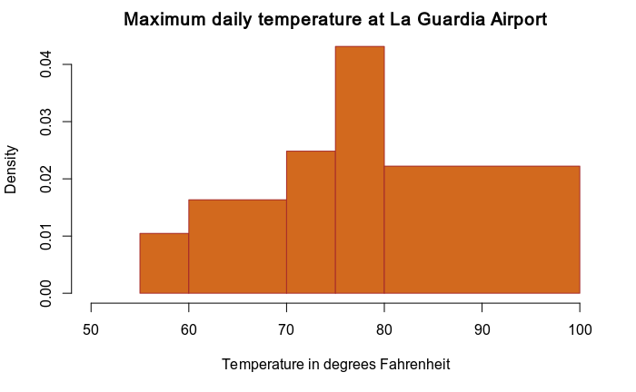

```r
hist(Temperature,
main="Maximum daily temperature at La Guardia Airport",
xlab="Temperature in degrees Fahrenheit",
xlim=c(50,100),
col="chocolate",
border="brown",
breaks=c(55,60,70,75,80,100)
)
```

# Scatter plots

A scatter plot provides a graphical view of the relationship between two sets of numbers.

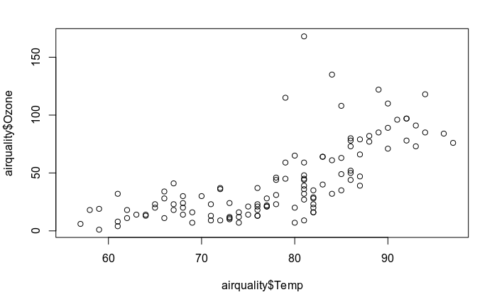

```r
plot(airquality$Temp, airquality$Ozone)
```

It is always common that the parameters could be adjusted. The parameters are same as strip chart.

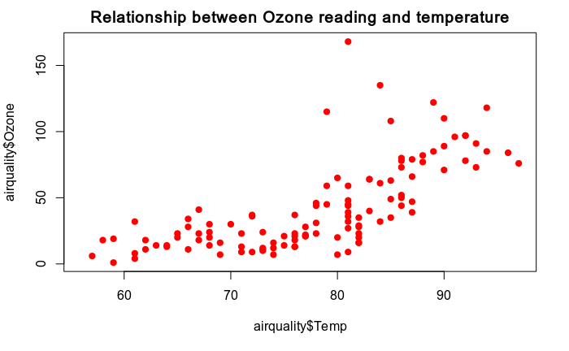

```r
plot(airquality$Temp, airquality$Ozone, col="red", pch =19, main="Relationship between Ozone reading and temperature")
```

## Plotting scatter plot for more than two variables

Since scatter plot is used to visualize the relationship between two variables, it is not proper to plot several variables in one plot. However, by creating a matrix of scatterplots, we could see the relationship between several variables.

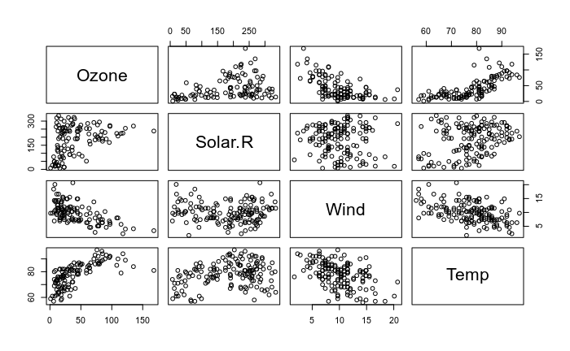

```r
pairs(airquality[,1:4])
```

# Pie Chart

The last plot we would try is **pie chart**. It is drawn using the **pie** function in R programming . This function takes in a vector of non-negative numbers. Here, since the airquality dataset is not proper for plotting pie chart, we will generate some dataset by ourselves.

## Simple pie chart

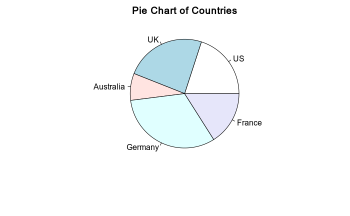

```r
slices <- c(10, 12,4, 16, 8)
lbls <- c("US", "UK", "Australia", "Germany", "France")
pie(slices, labels = lbls, main="Pie Chart of Countries")
```

It is kind of basic form, however, it is a little hard to get the ratio on the plot. What if we could add the percentage value with the annotation?

## Pie Chart with Annotated Percentages

To add the percentage as annotation, what we should do is calculate the percentage and creat the labels for the value. The total percentage should be 100%

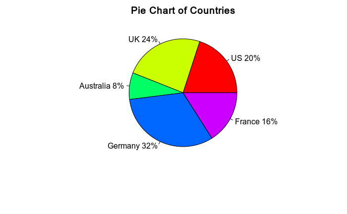

```r
pct <- round(slices/sum(slices)*100)
lbls <- paste(lbls, pct) # add percents to labels
lbls <- paste(lbls,"%",sep="") # ad % to labels
pie(slices,labels = lbls, col=rainbow(length(lbls)),
   main="Pie Chart of Countries")
```

## 3D pie chart

What if we could manage 3D pie chart which we could create on Excel? The *pie3D( )* function in the **plotrix** package provides 3D exploded pie charts.

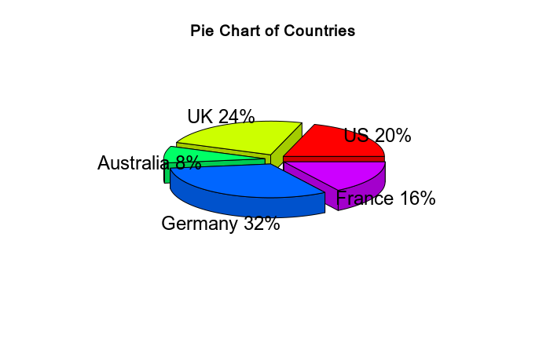

```r
library(plotrix)
pie3D(slices,labels=lbls,explode=0.1, main="Pie Chart of Countries ")
```